# Instructions

- Some parts of the code are already done for you
- You need to execute all the cells
- You need to add the code where ever you see `"#### Add your code here ####"`
- Marks are mentioned along with the cells

# Face recognition

Task is to recognize a faces

### Dataset

**Aligned Face Dataset from Pinterest**

This dataset contains 10.770 images for 100 people. All images are taken from 'Pinterest' and aligned using dlib library.

```python
%tensorflow_version 2.x #select tensorflow v2
```

```
`%tensorflow_version` only switches the major version: 1.x or 2.x.
You set: `2.x #select tensorflow v2`. This will be interpreted as: `2.x`.


TensorFlow 2.x selected.
```

```python
import tensorflow
tensorflow.__version__
```

```
'2.1.0'
```

#### Mount Google drive if you are using google colab

- We recommend using Google Colab as you can face memory issues and longer runtimes while running on local

```python
from google.colab import drive #import drive
drive.mount('/content/drive') #mount drive
```

```
Go to this URL in a browser: https://accounts.google.com/o/oauth2/auth?client_id=947318989803-6bn6qk8qdgf4n4g3pfee6491hc0brc4i.apps.googleusercontent.com&redirect_uri=urn%3aietf%3awg%3aoauth%3a2.0%3aoob&response_type=code&scope=email%20https%3a%2f%2fwww.googleapis.com%2fauth%2fdocs.test%20https%3a%2…

Enter your authorization code:
··········
```

#### Change current working directory to project folder (1 mark)

```python
import os,sys #import os, system

os.chdir('/content/drive/My Drive/CV/Face Recognition') #change directory
!ls #list files in directory
sys.path.append('/content/drive/My Drive/CV/Face Recognition') #append path
```

```
'Aligned Face Dataset from Pinterest.zip'   PINS
 embeddings.h5				    vgg_face_weights.h5
```

### Extract the zip file (5 Marks)

- Extract Aligned Face Dataset from Pinterest.zip

```python
import zipfile #import zipfile

zipdata = zipfile.ZipFile('Aligned Face Dataset from Pinterest.zip','r') #load zipfile
#zipdata.extractall() #extract zipfile
```

### Function to load images

- Define a function to load the images from the extracted folder and map each image with person id

```python
import numpy as np
import os

class IdentityMetadata():
    def __init__(self, base, name, file):
        # print(base, name, file)
        # dataset base directory
        self.base = base
        # identity name
        self.name = name
        # image file name
        self.file = file

    def __repr__(self):
        return self.image_path()

    def image_path(self):
        return os.path.join(self.base, self.name, self.file)

def load_metadata(path):
    metadata = []
    for i in os.listdir(path):
        for f in os.listdir(os.path.join(path, i)):
            # Check file extension. Allow only jpg/jpeg' files.
            ext = os.path.splitext(f)[1]
            if ext == '.jpg' or ext == '.jpeg':
                metadata.append(IdentityMetadata(path, i, f))
    return np.array(metadata)

# metadata = load_metadata('images')
metadata = load_metadata('PINS')
```

### Define function to load image

- Define a function to load image from the metadata

```python
import cv2
def load_image(path):
    img = cv2.imread(path, 1)
    # OpenCV loads images with color channels
    # in BGR order. So we need to reverse them
    return img[...,::-1]
```

#### Load a sample image (5 Marks)

- Load one image using the function "load_image"

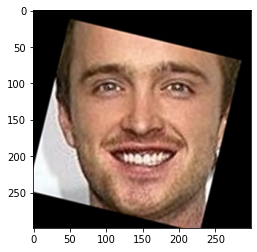

```python
import matplotlib.pyplot as plt #import pyplot
image = load_image(metadata[20].image_path()) #load image
plt.imshow(image) #display image
```

### VGG Face model

- Here we are giving you the predefined model for VGG face

```python
from tensorflow.keras.models import Sequential
from tensorflow.keras.layers import ZeroPadding2D, Convolution2D, MaxPooling2D, Dropout, Flatten, Activation

def vgg_face():
    model = Sequential()
    model.add(ZeroPadding2D((1,1),input_shape=(224,224, 3)))
    model.add(Convolution2D(64, (3, 3), activation='relu'))
    model.add(ZeroPadding2D((1,1)))
    model.add(Convolution2D(64, (3, 3), activation='relu'))
    model.add(MaxPooling2D((2,2), strides=(2,2)))

    model.add(ZeroPadding2D((1,1)))
    model.add(Convolution2D(128, (3, 3), activation='relu'))
    model.add(ZeroPadding2D((1,1)))
    model.add(Convolution2D(128, (3, 3), activation='relu'))
    model.add(MaxPooling2D((2,2), strides=(2,2)))

    model.add(ZeroPadding2D((1,1)))
    model.add(Convolution2D(256, (3, 3), activation='relu'))
    model.add(ZeroPadding2D((1,1)))
    model.add(Convolution2D(256, (3, 3), activation='relu'))
    model.add(ZeroPadding2D((1,1)))
    model.add(Convolution2D(256, (3, 3), activation='relu'))
    model.add(MaxPooling2D((2,2), strides=(2,2)))

    model.add(ZeroPadding2D((1,1)))
    model.add(Convolution2D(512, (3, 3), activation='relu'))
    model.add(ZeroPadding2D((1,1)))
    model.add(Convolution2D(512, (3, 3), activation='relu'))
    model.add(ZeroPadding2D((1,1)))
    model.add(Convolution2D(512, (3, 3), activation='relu'))
    model.add(MaxPooling2D((2,2), strides=(2,2)))

    model.add(ZeroPadding2D((1,1)))
    model.add(Convolution2D(512, (3, 3), activation='relu'))
    model.add(ZeroPadding2D((1,1)))
    model.add(Convolution2D(512, (3, 3), activation='relu'))
    model.add(ZeroPadding2D((1,1)))
    model.add(Convolution2D(512, (3, 3), activation='relu'))
    model.add(MaxPooling2D((2,2), strides=(2,2)))

    model.add(Convolution2D(4096, (7, 7), activation='relu'))
    model.add(Dropout(0.5))
    model.add(Convolution2D(4096, (1, 1), activation='relu'))
    model.add(Dropout(0.5))
    model.add(Convolution2D(2622, (1, 1)))
    model.add(Flatten())
    # model.add(Activation('relu'))
    model.add(Activation('softmax'))
    return model
```

#### Load the model (5 Marks)

- Load the model defined above
- Then load the given weight file named "vgg_face_weights.h5"

```python
WEIGHTS_FILE = 'vgg_face_weights.h5' #weights file
model = vgg_face() #load model
model.load_weights(WEIGHTS_FILE) #load weights
model.summary() #model summary
```

```
Model: "sequential"
_________________________________________________________________
Layer (type)                 Output Shape              Param #
=================================================================
zero_padding2d (ZeroPadding2 (None, 226, 226, 3)       0
_________________________________________________________________
conv2d (Conv2D)              (None, 224, 224, 64)      1792
_________________________________________________________________
zero_padding2d_1 (ZeroPaddin (None, 226, 226, 64)      0
_________________________________________________________________
conv2d_1 (Conv2D)            (None, 224, 224, 64)      36928
_________________________________________________________________
max_pooling2d (MaxPooling2D) (None, 112, 112, 64)      0
_________________________________________________________________
zero_padding2d_2 (ZeroPaddin (None, 114, 114, 64)      0
_________________________________________________________________
conv2d_2 (Conv2D)            (None, 112, 112, 128)     73856
_________________________________________________________________
zero_padding2d_3 (ZeroPaddin (None, 114, 114, 128)     0
_________________________________________________________________
conv2d_3 (Conv2D)            (None, 112, 112, 128)     147584
_________________________________________________________________
max_pooling2d_1 (MaxPooling2 (None, 56, 56, 128)       0
_________________________________________________________________
zero_padding2d_4 (ZeroPaddin (None, 58, 58, 128)       0
_________________________________________________________________
conv2d_4 (Conv2D)            (None, 56, 56, 256)       295168
_________________________________________________________________
zero_padding2d_5 (ZeroPaddin (None, 58, 58, 256)       0
_________________________________________________________________
conv2d_5 (Conv2D)            (None, 56, 56, 256)       590080
_________________________________________________________________
zero_padding2d_6 (ZeroPaddin (None, 58, 58, 256)       0
_________________________________________________________________
conv2d_6 (Conv2D)            (None, 56, 56, 256)       590080
_________________________________________________________________
max_pooling2d_2 (MaxPooling2 (None, 28, 28, 256)       0
_________________________________________________________________
zero_padding2d_7 (ZeroPaddin (None, 30, 30, 256)       0
_________________________________________________________________
```

[output cut: 29 more lines]

```
_________________________________________________________________
conv2d_14 (Conv2D)           (None, 1, 1, 4096)        16781312
_________________________________________________________________
dropout_1 (Dropout)          (None, 1, 1, 4096)        0
_________________________________________________________________
conv2d_15 (Conv2D)           (None, 1, 1, 2622)        10742334
_________________________________________________________________
flatten (Flatten)            (None, 2622)              0
_________________________________________________________________
activation (Activation)      (None, 2622)              0
=================================================================
Total params: 145,002,878
Trainable params: 145,002,878
Non-trainable params: 0
_________________________________________________________________
```

### Get vgg_face_descriptor

```python
from tensorflow.keras.models import Model
vgg_face_descriptor = Model(inputs=model.layers[0].input, outputs=model.layers[-2].output)
```

### Generate embeddings for each image in the dataset

- Given below is an example to load the first image in the metadata and get its embedding vector from the pre-trained model.

```python
# Get embedding vector for first image in the metadata using the pre-trained model
img_path = metadata[0].image_path()
img = load_image(img_path)

# Normalising pixel values from [0-255] to [0-1]: scale RGB values to interval [0,1]
img = (img / 255.).astype(np.float32)

img = cv2.resize(img, dsize = (224,224))
print(img.shape)

# Obtain embedding vector for an image
# Get the embedding vector for the above image using vgg_face_descriptor model and print the shape

embedding_vector = vgg_face_descriptor.predict(np.expand_dims(img, axis=0))[0]
print(embedding_vector.shape)
```

```
(224, 224, 3)
(2622,)
```

### Generate embeddings for all images (5 marks)

- Write code to iterate through metadata and create embeddings for each image using `vgg_face_descriptor.predict()` and store in a list with name `embeddings`
- If there is any error in reading any image in the dataset, fill the emebdding vector of that image with 2622-zeroes as the final embedding from the model is of length 2622.

```python
def generate_embeddings(meta): #define function which takes metadata as parameter
  embeddings = np.zeros((meta.shape[0], 2622)) #Embedding vector filled with zeroes
  for idx, meta in enumerate(meta): #iterate metadata
     try: #try
       img = load_image(meta.image_path()) #load image
       img = (img / 255.).astype(np.float32) #Normalising pixel values from [0-255] to [0-1]
       img = cv2.resize(img, dsize = (224,224)) #scale RGB values to interval [0,1]
       embeddings[idx] = vgg_face_descriptor.predict(np.expand_dims(img, axis=0))[0] #obtain embedding vector for image
     except Exception as e: #catch exception if any generated during runtime
       print('Embeddings not generated for image:', meta.image_path(), 'Error:', str(e))
  return embeddings #return embeddings
```

```python
#embeddings = generate_all_embeddings(metadata)
```

- The generation of embeddings takes a lot of time to execute, so saving all generated embeddings in HDF5 file.

```python
import h5py #import h5py
hdf_file = 'embeddings.h5' #filename for h5 file

if os.path.isfile(hdf_file) and os.path.getsize(hdf_file) > 0: #check if file already exists
  hf = h5py.File(hdf_file, 'r') #load file
  n1 = hf.get('embeddings') #load embeddings from the file
  embeddings = np.array(n1) #convert data into array
else: #if file doesnot exists
  embeddings = generate_embeddings(metadata) #generate embeddings
  with open(hdf_file, 'wb'): #create file
    hf = h5py.File(hdf_file, 'w')
    hf.create_dataset('embeddings', data=embeddings)#insert embeddings into file
    hf.close()#close file
```

### Function to calculate distance between given 2 pairs of images.

- Consider distance metric as "Squared L2 distance"
- Squared l2 distance between 2 points (x1, y1) and (x2, y2) = (x1-x2)^2 + (y1-y2)^2

```python
import numpy as np
def distance(emb1, emb2):
    return np.sum(np.square(emb1 - emb2))
```

#### Plot images and get distance between the pairs given below

- 2, 3 and 2, 180
- 30, 31 and 30, 100
- 70, 72 and 70, 115

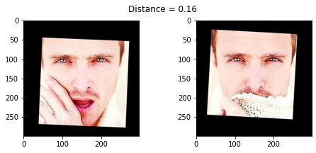

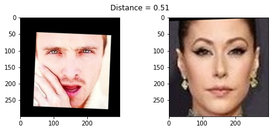

```python
import matplotlib.pyplot as plt

def show_pair(idx1, idx2):
    plt.figure(figsize=(8,3))
    plt.suptitle(f'Distance = {distance(embeddings[idx1], embeddings[idx2]):.2f}')
    plt.subplot(121)
    plt.imshow(load_image(metadata[idx1].image_path()))
    plt.subplot(122)
    plt.imshow(load_image(metadata[idx2].image_path()));

show_pair(2, 3)
show_pair(2, 180)
```

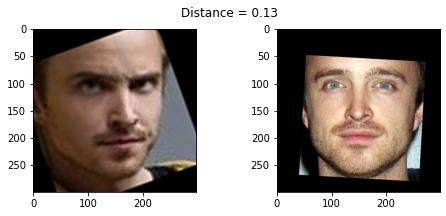

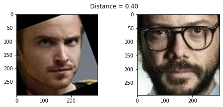

```python
show_pair(30, 31) #distance between 30,31
show_pair(30, 100) #distance between 30, 100
```

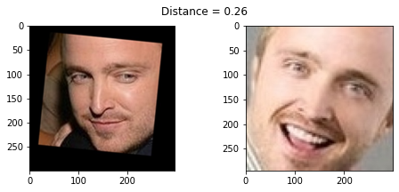

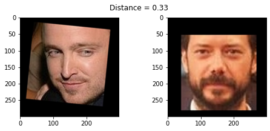

```python
show_pair(70, 72) #distance between 70, 72
show_pair(70, 115) #distance between 70, 115
```

### Create train and test sets (5 marks)

- Create X_train, X_test and y_train, y_test
- Use train_idx to seperate out training features and labels
- Use test_idx to seperate out testing features and labels

```python
train_idx = np.arange(metadata.shape[0]) % 9 != 0
test_idx = np.arange(metadata.shape[0]) % 9 == 0

#creating X_train, X_test
X_train = embeddings[train_idx]
X_test = embeddings[test_idx]

#creating y_train, y_test
Y = np.array([i.name for i in metadata])
y_train = Y[train_idx]
y_test =  Y[test_idx]
```

### Encode the Labels (5 marks)

- Encode the targets
- Use LabelEncoder

```python
from sklearn.preprocessing import LabelEncoder #import labelencoder

encoder = LabelEncoder() #LabelEncoder
y_train = encoder.fit_transform(y_train) #encode y_train
y_test =  encoder.fit_transform(y_test) #encode y_test
```

### Standardize the feature values (5 marks)

- Scale the features using StandardScaler

```python
from sklearn.preprocessing import StandardScaler #import StandardScaler

Scaler = StandardScaler() #standardscaler
X_train = Scaler.fit_transform(X_train) #scale X_train
X_test = Scaler.fit_transform(X_test) #scale X_test
```

### Reduce dimensions using PCA (5 Marks)

- Reduce feature dimensions using Principal Component Analysis

```python
from sklearn.decomposition import PCA #import PCA

pca = PCA() #pca
pca.fit(X_train) #fit pca
explained_variance = pca.explained_variance_ratio_ #calculate explained_variance_ratio
```

```python
# cumulative sum of variance
round_variance = np.round(explained_variance, decimals=3)*100
np.cumsum(round_variance)
```

```
array([13.6, 19. , 23. , ..., 91.7, 91.7, 91.7])
```

```python
import plotly.express as px #import plotly

fig = px.line(np.cumsum(round_variance), list(range(1,2623)), np.cumsum(round_variance), title='Explained variance') #lineplot
fig.update_layout(xaxis_title="Eigen Values", yaxis_title="Explained Variance")
fig.show() #show figure
```

[interactive chart not shown]

- The plot is not displayed here due to some glitch after downloding the ipynb from google colab to convert the file into .html
- Above plot is included below, to display the findings.

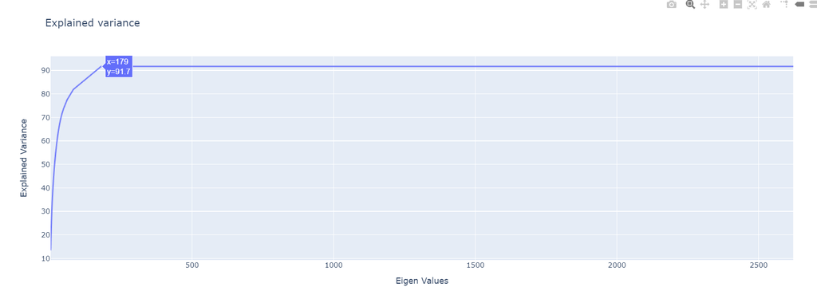

```python
from IPython.display import Image
Image(filename='plot.PNG',width=1000,height=900) #include Image
```

- From above Line plot it can be observed that 179 features are able to cover 91.7% variance from the data.

```python
pca = PCA(n_components=179, whiten=True) #selecting 179 features

X_train = pca.fit_transform(X_train) #fit and transform
X_test = pca.transform(X_test) #fit and transform
```

### Build a Classifier (3 marks)

- Use SVM Classifier to predict the person in the given image
- Fit the classifier and print the score

```python
from sklearn.svm import SVC #import SVC

svc = SVC(gamma='auto',kernel='rbf') #SVC
svc.fit(X_train,y_train)#fit
svc.score(X_test,y_test)#evaluate
```

```
0.960735171261487
```

```python
from sklearn.metrics import accuracy_score,confusion_matrix #for accuracy matrices
from sklearn.metrics import classification_report,precision_score,recall_score #for accuracy matrices

y_predi = svc.predict(X_test) #Predict
print('\033[1m''->'*63)
print('\033[1m''Confusion Matrix\n',confusion_matrix(y_test,y_predi)) #for confusion matrix
print('-'*30)
print('Accuracy of SVM Classifier :{:.2f}'.format(accuracy_score(y_test,y_predi))) #for accuracy score
print('Precision of SVM Classifier :{:.2f}'.format(precision_score(y_test,y_predi,average='micro'))) #for accuracy score
print('Recall of SVM Classifier :{:.2f}'.format(recall_score(y_test,y_predi,average='micro'))) #for accuracy score
print('-'*30)
#print('\n Classification Report\n',classification_report(y_test,y_predi)) #for classification report
print('->'*63)
```

```
->->->->->->->->->->->->->->->->->->->->->->->->->->->->->->->->->->->->->->->->->->->->->->->->->->->->->->->->->->->->->->->
Confusion Matrix
 [[10  0  0 ...  0  0  0]
 [ 0 10  0 ...  0  0  0]
 [ 0  0 13 ...  0  0  0]
 ...
 [ 0  0  0 ... 11  0  0]
 [ 0  0  0 ...  0 12  0]
 [ 0  0  0 ...  0  0 12]]
------------------------------
Accuracy of SVM Classifier :0.96
Precision of SVM Classifier :0.96
Recall of SVM Classifier :0.96
------------------------------
->->->->->->->->->->->->->->->->->->->->->->->->->->->->->->->->->->->->->->->->->->->->->->->->->->->->->->->->->->->->->->->
```

- SVM is able to produce 96% accuracy, precision and recall.

### Test results (2 mark)

- Take 10th image from test set and plot the image
- Report to which person(folder name in dataset) the image belongs to

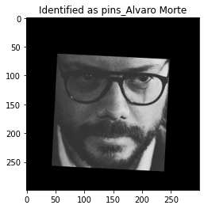

```python
import warnings
# Suppress LabelEncoder warning
warnings.filterwarnings('ignore')

example_idx = 10

example_image = load_image(metadata[test_idx][example_idx].image_path())
example_prediction = svc.predict([X_test[example_idx]])
example_identity = encoder.inverse_transform(example_prediction)[0]

plt.imshow(example_image)
plt.title(f'Identified as {example_identity}');
```

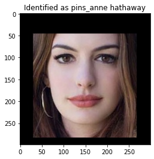

```python
example_idx = 800

example_image = load_image(metadata[test_idx][example_idx].image_path())
example_prediction = svc.predict([X_test[example_idx]])
example_identity = encoder.inverse_transform(example_prediction)[0]

plt.imshow(example_image)
plt.title(f'Identified as {example_identity}');
```

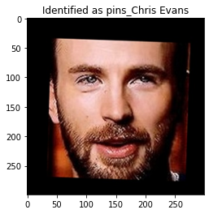

```python
example_idx = 150

example_image = load_image(metadata[test_idx][example_idx].image_path())
example_prediction = svc.predict([X_test[example_idx]])
example_identity = encoder.inverse_transform(example_prediction)[0]

plt.imshow(example_image)
plt.title(f'Identified as {example_identity}');
```